# Text Data

Text can also be visualized, but unlike numeric variables, text usually needs some extra preparation before plotting. Words appear in different forms, some words are very common but not very informative, and some meaningful ideas are expressed as phrases rather than as single words.

The goal is not only to produce attractive plots, but also to understand what each plot is good for.

## 1. Get the text data

Let us begin with a data frame containing some old tweets from D.Trump:

```r
rm(list = ls())

link1 = "https://github.com/MagallanesAtAlacip/datafiles/"
link2 = "raw/main/text/trumps.csv"


trumpLink = paste0(link1, link2)
allTweets = read.csv(trumpLink, stringsAsFactors = FALSE)
```

The data has these columns:

```r
names(allTweets)
```

```
## [1] "created_at"     "text"           "is_retweet"     "favorite_count"
## [5] "retweet_count"  "Hour"           "Day"            "Date"
```

The column with the tweet text contains entries like these:

```r
head(allTweets$text, 2)
```

```
## [1] ".@DonYoungAK really produces for Alaska. He is an incredible Congressman who loves his State and works tirelessly for it. Strong on Public Lands, Energy, and our Second Amendment. He will never let you down, and has my Complete and Total Endorsement! https://t.co/cUR3zuUfs6"
## [2] "...She will be a great Senator, and has my Complete and Total Endorsement! https://t.co/7yHPhxqQVS"
```

## 2. Select the observations of interest

This data frame has several columns that allow subsetting. In this example, I will keep only tweets that are **not retweets**:

```r
SomeTrumpTweets = allTweets[allTweets$is_retweet == FALSE, ]
SomeTrumpTweets = SomeTrumpTweets[, c("created_at", "text")]

head(SomeTrumpTweets, 3)
```

```
##            created_at
## 1 2020-08-13 23:26:50
## 2 2020-08-13 23:23:26
## 3 2020-08-13 23:23:25
##                                                                                                                                                                                                                                                                                 text
## 1 .@DonYoungAK really produces for Alaska. He is an incredible Congressman who loves his State and works tirelessly for it. Strong on Public Lands, Energy, and our Second Amendment. He will never let you down, and has my Complete and Total Endorsement! https://t.co/cUR3zuUfs6
## 2                                                                                                                                                                                 ...She will be a great Senator, and has my Complete and Total Endorsement! https://t.co/7yHPhxqQVS
## 3                                                                  .@CynthiaMLummis is a friend of mine and a great woman. She is running for Senate in the very Special State of Wyoming. Cynthia is Strongly for our Military, our Vets, and protection of the Second Amendment...
```

At this point, we still have complete text messages. To visualize text, we first need to break each message into smaller units.

## 3. Turn text into plottable words

This process starts by what is called **tokenization**: splitting phrases into individual words.

```r
library(dplyr)
library(tidytext)

SomeTrumpTweets |>
  unnest_tokens(
    output = EachWord,
    input  = text,
    token  = "words"
  ) |>head()
```

```
##            created_at   EachWord
## 1 2020-08-13 23:26:50 donyoungak
## 2 2020-08-13 23:26:50     really
## 3 2020-08-13 23:26:50   produces
## 4 2020-08-13 23:26:50        for
## 5 2020-08-13 23:26:50     alaska
## 6 2020-08-13 23:26:50         he
```

Notice that we named a new column `EachWord`, and in fact it has just one word from the tweet. The tweet message has been splitted or expanded into multiple rows, one row per word. It is useful to keep track of which tweet each word came from, like a long format ID. Currently, the `created_at` might work, but a simpler solution is to create a sequential ID:

```r
SomeTrumpTweets|>
  mutate(tweet_id = row_number())|>
  unnest_tokens(
    output = EachWord,
    input  = text,
    token  = "words"
  ) |>head()
```

```
##            created_at tweet_id   EachWord
## 1 2020-08-13 23:26:50        1 donyoungak
## 2 2020-08-13 23:26:50        1     really
## 3 2020-08-13 23:26:50        1   produces
## 4 2020-08-13 23:26:50        1        for
## 5 2020-08-13 23:26:50        1     alaska
## 6 2020-08-13 23:26:50        1         he
```

Let’s save that object:

```r
WordsIn_SomeTrumpTweets = SomeTrumpTweets|>
  mutate(tweet_id = row_number())|>
  unnest_tokens(
    output = EachWord,
    input  = text,
    token  = "words"
  )
```

Notice that the date is repeated for every word coming from the same tweet.

How many word-tokens do we have now?

```r
nrow(WordsIn_SomeTrumpTweets)
```

```
## [1] 3028
```

This number includes repeated words, which is useful because frequency is often our first summary of text. We still have some pending pre processing.

### 3.1. Remove common words: stopwords

Many very frequent words carry little substantive meaning. Words such as *the*, *and*, *of*, or *to* are useful for grammar, but not always useful for analysis. These are called **stopwords**.

```r
data(stop_words)
head(stop_words)
```

```
## # A tibble: 6 × 2
##   word      lexicon
##   <chr>     <chr>
## 1 a         SMART
## 2 a's       SMART
## 3 able      SMART
## 4 about     SMART
## 5 above     SMART
## 6 according SMART
```

Now let us remove them:

```r
WordsIn_SomeTrumpTweets = WordsIn_SomeTrumpTweets |>
  anti_join(stop_words, by = c("EachWord" = "word"))

nrow(WordsIn_SomeTrumpTweets)
```

```
## [1] 1496
```

After removing stopwords, the number of rows decreases because many very common words are filtered out.

This does **not** mean the remaining words are automatically important. It only means we are removing words that are usually too general to help interpretation.

## 3.2. Getting rid of other unneeded words

Take a look at the most repeated words (tokens):

```r
sort(table(WordsIn_SomeTrumpTweets$EachWord))|>tail(10)
```

```
##
##       complete           news        support infrastructure        service
##             12             12             13             14             14
##          usdot         people            bus          https           t.co
##             17             18             20             54             54
```

Then we can safely drop some of those:

```r
badWords = c("https", "t.co")

WordsIn_SomeTrumpTweets_clean = WordsIn_SomeTrumpTweets |>
  filter(!EachWord %in% badWords)
```

Now, let’s keep the ones that appeared more than 4 times:

```r
moreThan_4 = WordsIn_SomeTrumpTweets_clean|>
  count(EachWord, name = "Counts", sort = TRUE) |>
  filter(Counts > 4)

head(moreThan_4, 10)
```

```
##          EachWord Counts
## 1             bus     20
## 2          people     18
## 3           usdot     17
## 4  infrastructure     14
## 5         service     14
## 6         support     13
## 7        complete     12
## 8            news     12
## 9     endorsement     11
## 10        federal     11
```

These are the words that appear most often after basic cleaning.

Before moving to more decorative plots, it is useful to begin with the clearest graph possible.

## 4. Options for plots

### 4.1. Ranked bar chart

A ranked bar chart is usually the best option when the goal is **comparison**.

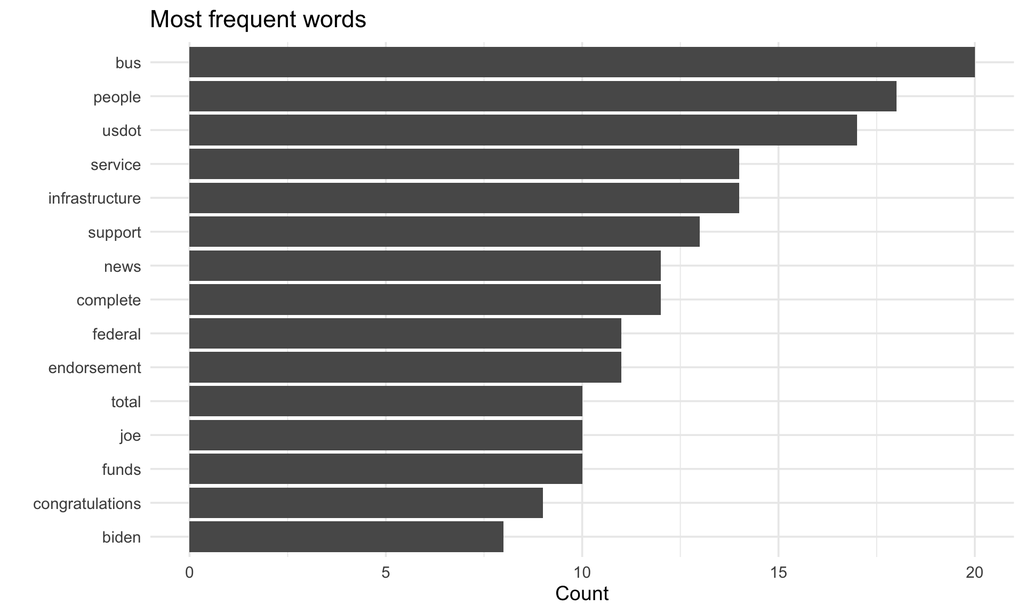

```r
library(ggplot2)

top_words = moreThan_4 |>
  slice_head(n = 15)

ggplot(top_words,
       aes(x = reorder(EachWord, Counts), y = Counts)) +
  geom_col() +
  coord_flip() +
  labs(
    x = "",
    y = "Count",
    title = "Most frequent words"
  ) +
  theme_minimal(base_size = 14)
```

This plot is very useful because it allows precise comparison. You can clearly see:

- which words are most frequent
- their ranking
- the size of the differences between them

For comparing frequencies, bar charts are usually better than word clouds.

### 4.2. Lollipop chart

A lollipop chart shows the same information as a bar chart, but with a lighter appearance.

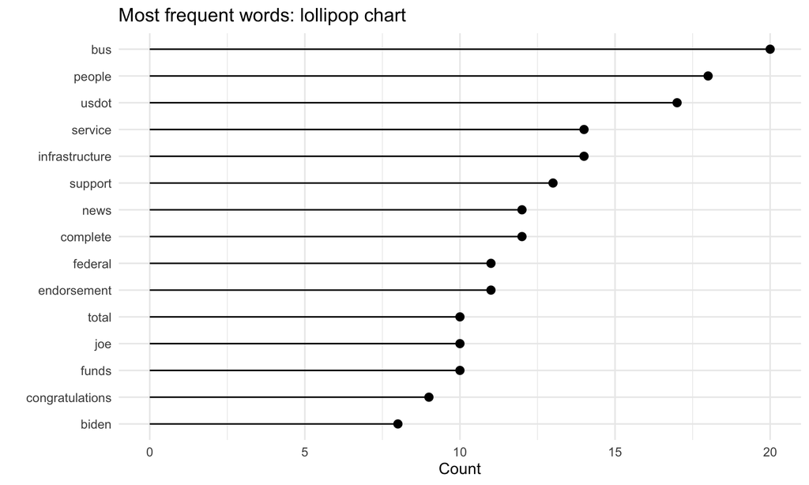

```r
ggplot(top_words,
       aes(x = reorder(EachWord, Counts), y = Counts)) +
  geom_segment(aes(xend = EachWord, y = 0, yend = Counts)) +
  geom_point(size = 3) +
  coord_flip() +
  labs(
    x = "",
    y = "Count",
    title = "Most frequent words: lollipop chart"
  ) +
  theme_minimal(base_size = 14)
```

This chart still prioritizes ranking and comparison, but it uses less visual weight than bars.

### 4.1. Word cloud

Now let us build the word cloud.

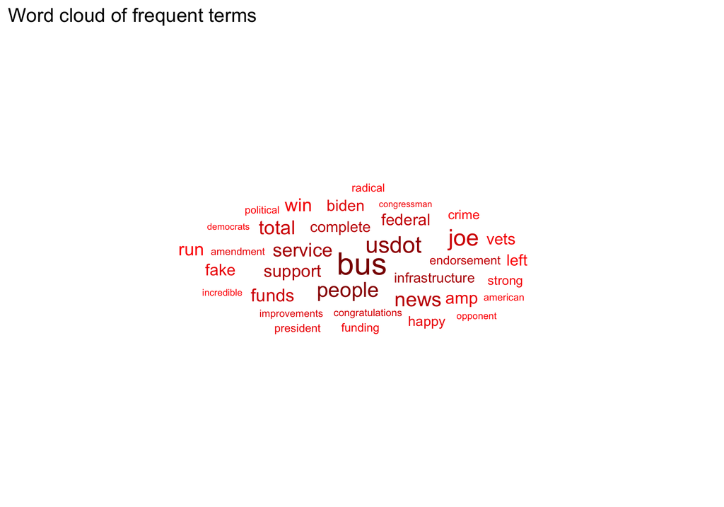

```r
library(ggwordcloud)

ggplot(moreThan_4,
       aes(label = EachWord,
           size  = Counts,
           color = Counts)) +
  geom_text_wordcloud_area(eccentricity = 0.7,
                           rm_outside = TRUE) +
  scale_size_area(max_size = 18) +
  scale_color_gradient(low = "red", high = "darkred") +
  theme_minimal(base_size = 16) +
  labs(title = "Word cloud of frequent terms")
```

Word clouds are often visually attractive, but they are not ideal for accurate comparison. They are better for quick engagement and general impression than for careful measurement.

### 4.2. Treemap

A treemap is another way to represent frequencies, this time using **area** of rectangles.

Install “treemapify” using this code:

```r
# install.packages("treemapify", type = "binary")
```

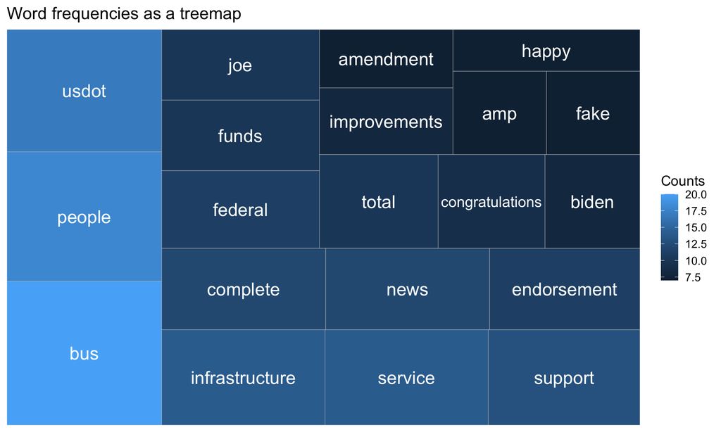

```r
library(treemapify)

ggplot(moreThan_4 |>
         slice_head(n = 20),
       aes(area = Counts, fill = Counts, label = EachWord)) +
  geom_treemap() +
  geom_treemap_text(place = "centre", colour = "white", reflow = TRUE) +
  labs(title = "Word frequencies as a treemap") +
  theme_minimal(base_size = 14)
```

Treemaps are compact and visually appealing, but they are not as precise as bars for comparing values.

## 5. A second example: reading from a TXT file

Not all text data comes from tweets. Sometimes you simply have a text file.

Suppose we have this file:

[figure not shown]

We can read it like this:

```r
LinkText = "https://github.com/MagallanesAtAlacip/datafiles/raw/main/text/sometext.txt"

otherText = read.delim(LinkText, header = FALSE)

head(otherText)
```

```
##                                                                                                                                                                                                                                                                                                          …
## 1                                                                                                                                                                                                                                                                                                        …
## 2                                                                                                                                                                                                                                                                                                        …
## 3       Over the past year, I’ve spent time at city council meetings, political rallies, homeless encampments, and rehabilitation facilities, trying to understand how the government can spend so much money with so little effect. While most of the debate has focused on tactical policy questions (B…
## 4                                                                                                                                                                                                                                                                                                     Sea…
## 5 On the surface, this argument has its own internal logic. Advocates point to Zillow and McKinsey studies that show a high correlation between rent hikes and homelessness in Seattle, for example. But correlation is not causation, and the survey data paint a remarkably different picture. Accordin…
## 6                                                                                                                                                                                                                                                                                                        …
```

Notice that a new row is created whenever a new paragraph or line break is found.

Now let us tokenize the text and remove stopwords and the above discovered *badWords*:

```r
otherText_words = otherText |>
  unnest_tokens(output = EachWord,
                input  = V1,
                token  = "words") |>
  anti_join(stop_words, by = c("EachWord" = "word")) |>
  filter(!EachWord %in% badWords)

head(otherText_words, 20)
```

```
##        EachWord
## 1       seattle
## 2         siege
## 3          past
## 4       emerald
## 5          city
## 6     explosion
## 7  homelessness
## 8         crime
## 9     addiction
## 10         2017
## 11         time
## 12        count
## 13     homeless
## 14         king
## 15       county
## 16       social
## 17     services
## 18       agency
## 19         home
## 20        found
```

Now compute frequencies:

```r
txt_counts = otherText_words |>
  count(EachWord, name = "Counts", sort = TRUE) |>
  filter(Counts > 4) # filtered by count

head(txt_counts, 10)
```

```
##        EachWord Counts
## 1      homeless     47
## 2  homelessness     46
## 3          city     40
## 4       seattle     37
## 5     addiction     21
## 6       percent     20
## 7        people     18
## 8        public     18
## 9      services     18
## 10      housing     16
```

## 6. Other Plots beyond raw counts

Once you have word counts or frequencies, you can prepare your word cloud:

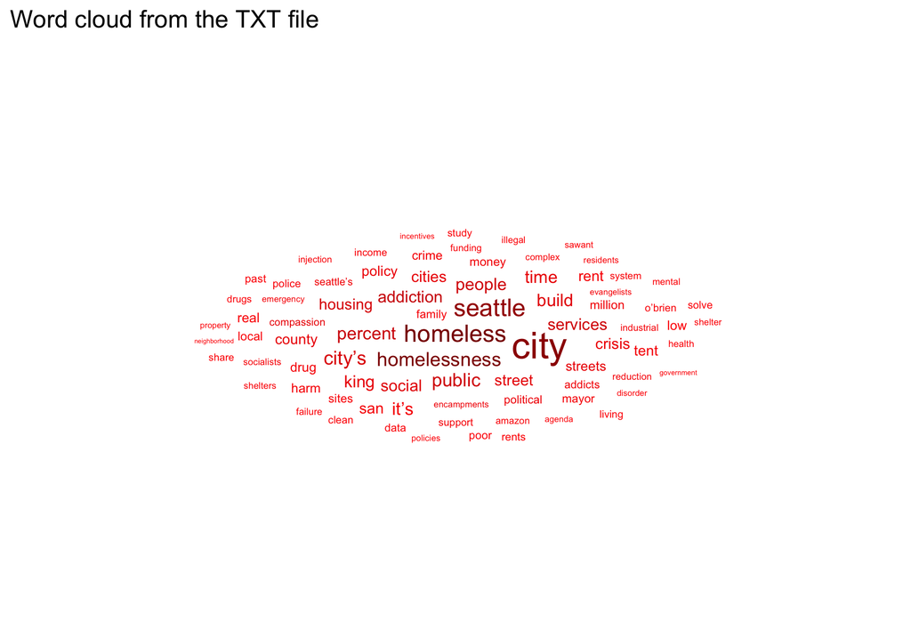

```r
ggplot(txt_counts,
       aes(label = EachWord,
           size  = Counts,
           color = Counts)) +
  geom_text_wordcloud_area(rm_outside = TRUE) +
  scale_size_area(max_size = 18) +
  scale_color_gradient(low = "red", high = "darkred") +
  theme_minimal(base_size = 16) +
  labs(title = "Word cloud from the TXT file")
```

And you ranked bars:

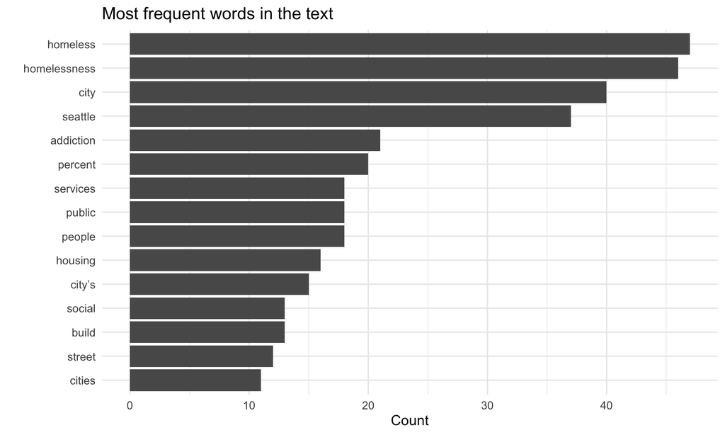

```r
txt_top15 = txt_counts |>
  slice_head(n = 15)

ggplot(txt_top15,
       aes(x = reorder(EachWord, Counts), y = Counts)) +
  geom_col() +
  coord_flip() +
  labs(
    x = "",
    y = "Count",
    title = "Most frequent words in the text"
  ) +
  theme_minimal(base_size = 14)
```

You may also use proportions instead of raw values as labels (counts still are represented on Y axis):

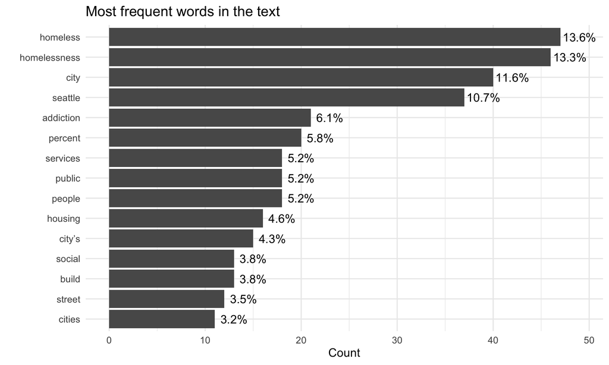

```r
ggplot(txt_top15,
       aes(x = reorder(EachWord, Counts), y = Counts)) +
  geom_col() +
  coord_flip() +
  geom_text(
    aes(label = paste0(round(100 * Counts / sum(Counts), 1), "%")),
    nudge_y = 2
  ) +
  labs(
    x = "",
    y = "Count",
    title = "Most frequent words in the text"
  ) +
  theme_minimal(base_size = 14)
```

However, other strategies beyond plotting frequencies are possible.

### 6.1 Co-occurrence networks

So far, we have treated words as isolated units. But language also has structure: some words tend to appear together.

A simple way to explore this is through **bigrams**, that is, pairs of words that appear next to each other. The **`unnest_tokens()`** is used again, but requesting consecutive pairs:

```r
bigrams = SomeTrumpTweets |>
  unnest_tokens(bigram, text, token = "ngrams", n = 2)

## see some
bigrams |>head()
```

```
##            created_at            bigram
## 1 2020-08-13 23:26:50 donyoungak really
## 2 2020-08-13 23:26:50   really produces
## 3 2020-08-13 23:26:50      produces for
## 4 2020-08-13 23:26:50        for alaska
## 5 2020-08-13 23:26:50         alaska he
## 6 2020-08-13 23:26:50             he is
```

The output above is not ready yet, we need to split the pairs:

```r
library(tidyr)
bigrams_inColumns = bigrams |>
                    separate_wider_delim(bigram,
                                         names = c("word1", "word2"),
                                         delim = " ")
bigrams_inColumns
```

```
## # A tibble: 2,907 × 3
##    created_at          word1       word2
##    <chr>               <chr>       <chr>
##  1 2020-08-13 23:26:50 donyoungak  really
##  2 2020-08-13 23:26:50 really      produces
##  3 2020-08-13 23:26:50 produces    for
##  4 2020-08-13 23:26:50 for         alaska
##  5 2020-08-13 23:26:50 alaska      he
##  6 2020-08-13 23:26:50 he          is
##  7 2020-08-13 23:26:50 is          an
##  8 2020-08-13 23:26:50 an          incredible
##  9 2020-08-13 23:26:50 incredible  congressman
## 10 2020-08-13 23:26:50 congressman who
## # ℹ 2,897 more rows
```

Some cleaning and sorted counts:

```r
bigram_counts_clean = bigrams_inColumns|>
                      filter(!word1 %in% stop_words$word,
                             !word2 %in% stop_words$word) |>
                      filter(!word1 %in% badWords,
                             !word2 %in% badWords) |>
                      count(word1, word2, sort = TRUE) |>
                      filter(n >= 5)
# see top
bigram_counts_clean |> head(10)
```

```
## # A tibble: 7 × 3
##   word1          word2              n
##   <chr>          <chr>          <int>
## 1 bus            service           12
## 2 total          endorsement       10
## 3 federal        infrastructure     8
## 4 infrastructure funds              8
## 5 support        bus                8
## 6 joe            biden              6
## 7 radical        left               5
```

#### 6.1.1 The creation of networks

As we have pairs, we can think of each word as a network node. If word are nodes, a link between them means they co occur. Notice this network model allows that a word may be connected to more than one other word.

We need `igraph` here

```r
library(igraph)

bigram_graph = graph_from_data_frame(bigram_counts_clean,directed = F)
bigram_graph
```

```
## IGRAPH 9e2dd9b UN-- 12 7 --
## + attr: name (v/c), n (e/n)
## + edges from 9e2dd9b (vertex names):
## [1] bus           --service        total         --endorsement
## [3] federal       --infrastructure infrastructure--funds
## [5] bus           --support        joe           --biden
## [7] radical       --left
```

The *bigram_graph* also has some attributes. It has `name` and `n`. The former is an **v**ertex (or node) attribute, and it is a **c**haracter, take a look:

```r
V(bigram_graph)$name
```

```
##  [1] "bus"            "total"          "federal"        "infrastructure"
##  [5] "support"        "joe"            "radical"        "service"
##  [9] "endorsement"    "funds"          "biden"          "left"
```

The latter (`n`) is an **e**dge attribute whose type is **n**umeric:

```r
E(bigram_graph)$n
```

```
## [1] 12 10  8  8  8  6  5
```

This came from our counts column in `bigram_counts_clean`.

You can easily produce a `bigram plot` like this:

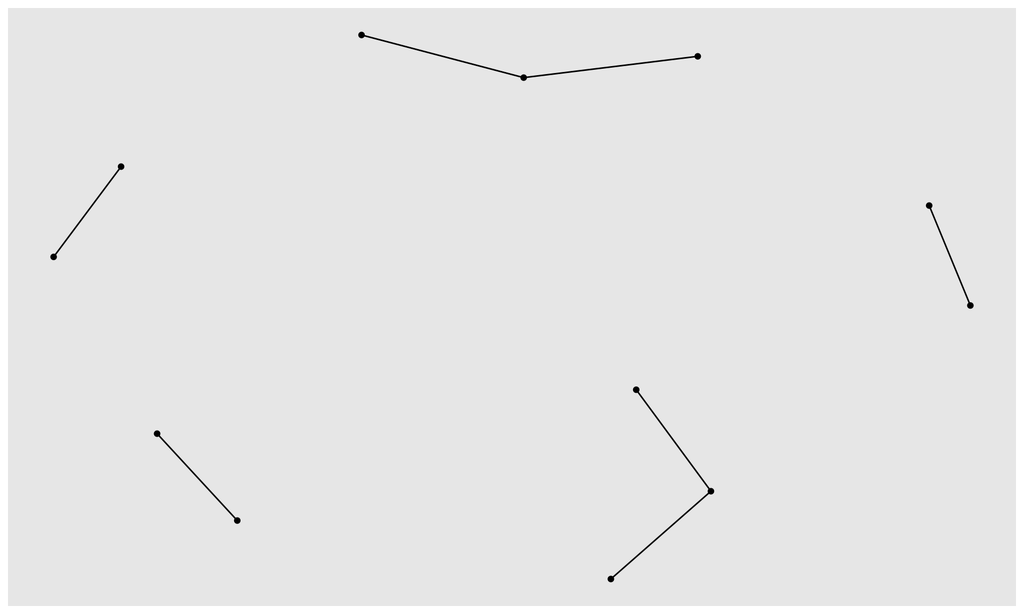

```r
library(ggraph)
ggraph::ggraph(bigram_graph ,layout="fr") +
  geom_edge_link() +
  geom_node_point()
```

The hardest part of drawing networks is deciding where to place nodes. The fr layout helps by simulating attraction between connected nodes and repulsion among all nodes. This usually spreads the graph clearly while bringing related nodes together, making clusters and central nodes easier to see.

We can improve this by adding names to the nodes:

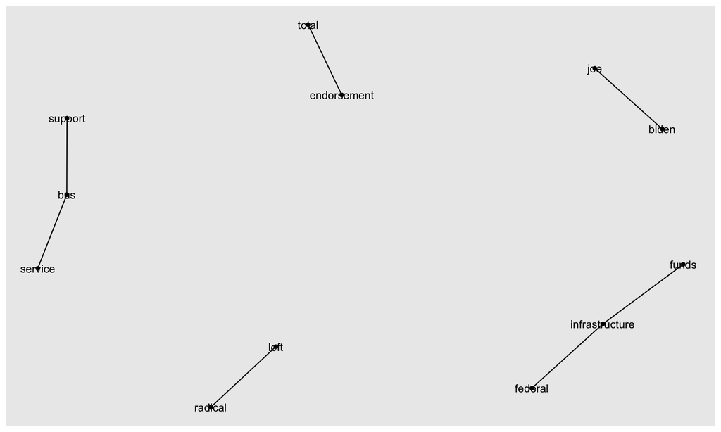

```r
ggraph::ggraph(bigram_graph,layout="fr") +
  geom_edge_link() +
  geom_node_point() +
  geom_node_text(aes(label = name))
```

We know that those edges have the *counts* attribute (`n`). We can use the line `width` channel to present the weight:

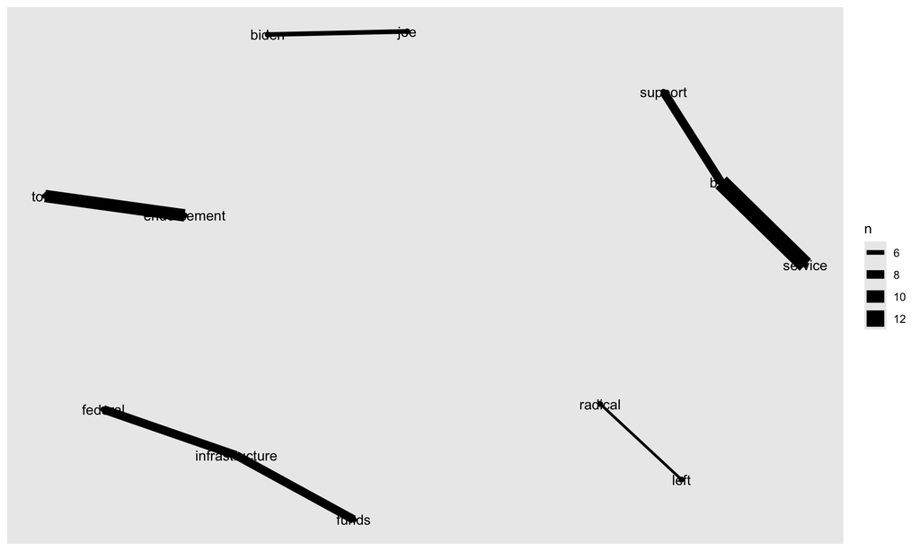

```r
ggraph::ggraph(bigram_graph, layout = "fr") +
  geom_edge_link(aes(width = n)) +
  geom_node_point() +
  geom_node_text(aes(label = name))
```

Let’s add some details for improvement:

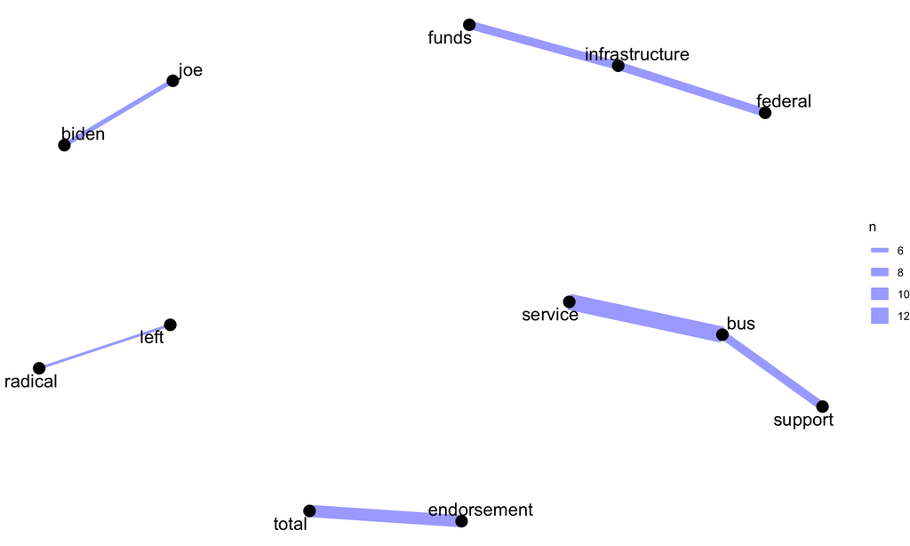

```r
ggraph::ggraph(bigram_graph, layout = "fr") + theme_void() +
  geom_edge_link(aes(width = n), alpha = 0.4, color='blue') +
  geom_node_point(size = 4) +
  geom_node_text(aes(label = name), repel = TRUE, size = 5)
```

This plot does not focus only on word frequency. Instead, it reveals **relationships between words**. That is often more meaningful than treating words separately.

This is where we end. I hope you liked the journey!